# QUARANTINE CODING ACADEMY

# R IS FOR ACTUARIES

## LESSON 3: CREATING A DOCUMENT USING R MARKDOWN

**NOTE: ALL SCRIPTS AND FILES CAN BE FOUND LINKED IN THE COMMENT SECTION BELOW**

### BACKGROUND - A DAY IN THE LIFE OF AN ACTUARY (LESSON 2 HW)

Your stakeholders have requested you to analyze the mortality dataset by 4 factors:

- Valuation Year
- Face Band
- Age Basis
- Gender

- Relative path for dataset
- New geometry - heatmap - with scaled colors - unscaled labels.
- Face bands set to vertical axis.
- Summarized all mortality tables using gather()

Before walking through this sample code - it might help to give more details around the gather() function.

- gather(Key,Value,Range)
- Key: name you want to give to the new dataset column with all the old column names
- Value: name you want toe give to the new dataset column with all the old column values
- Range: range of columns to be stacked on top of each other
- In our homework example key is all the mortality table names and value is all the actual to expected values
- In order to plot different levels in ggplot - need data in long format
- For example below: gather(YEAR,SALES,2015:2016)

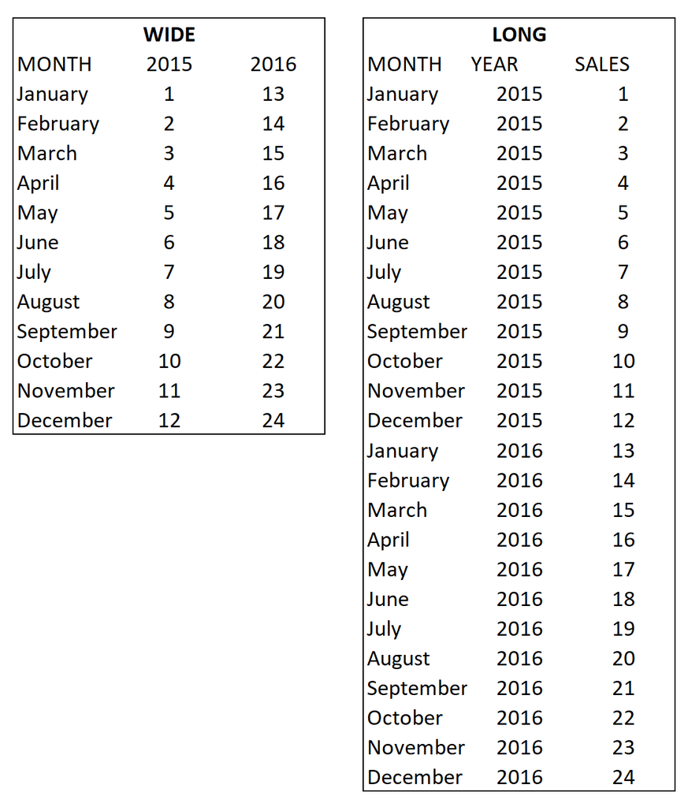

### Final Document

Now that we have finished our analysis in .R - it is time to document and communicate our results. It would not be acceptable to just send our manager our script - so we need to create a more user-friendly and informative document. We do this using R - and the final product looks like this (open saved HTML document).

Let’s go through the process of taking our R script and building the final document.

# FUNDAMENTALS OF BUILDING A MARKDOWN DOCUMENT

Very similar to working with our R Script.

1. File - New File - R Notebook
2. File - Save As - Save to your Working Directory
3. Session - Set Working Directory - To Source File Location

A very simplified way of viewing a Markdown document is just a combination of 2 components that you can see in the initial RMD we saved.

- Coding (R) editor
- Text editor

Both of these have their own syntax. We learned the basics of R syntax in lessons 1 and 2. There is nothing more to learn here. We can just copy and paste our code from our .R script into code snippets here.

Creating an R Markdown document simply consists of going back and forth between these 2 components. The material from lessons 1 and 2 give you a solid background for use when working with R. Working with the text editor can be as simple as just typing your summary. The only syntax you need is for formatting (things like bold, etc). Generally, there are just a few formats that you will need to master. Similar to the way you start most macros with a recorded version, you can use this sample document as a template. Translating from the RMD version to the HTML will give you a very good fundamental background. Alternatively or additionally, there are several resources available online. You will ultimately learn as much as you need and want.

### START WITH MARKDOWN - FIRST FORMATTED TEXT SNIPPET

Next add some text. Here we are introduced to some Markdown syntax. Don’t need to memorize - use a template or google. Knit here and we see our first text. Our document is beginning to take shape.

### START WITH MARKDOWN - FIRST GRAPH

The rest of the document is alternating between text and code snippets.

Once complete - using only R - we have:

- Imported a raw dataset with 1.4m rows of data
- Cleaned and summarized our data as requested.
- Used this summarized data to create visualizations for analysis.
- Documented our findings in an HTML document we created for our manager.
- Saved an RMD file that contains the entire process for any stakeholder to review.

This concludes week 3. Next week we will complete the series with: AN INTRODUCTION TO R SHINY ( the best lesson of all !!!)

HOMEWORK: REVIEW LESSONS 1-3